# Homework 2 - Asu Naz Yıldırım

```
n= 56127

node), split, n, loss, yval, (yprob)
      * denotes terminal node

 1) root 56127 31979 1 (0.43023857 0.29554403 0.27421740)
   2) Assists___home>=0.5 23489  8899 1 (0.62114181 0.14730299 0.23155520)
     4) Goals___away< 1.5 19616  6196 1 (0.68413540 0.09803222 0.21783238)
       8) Goals___home>=1.5 6030   678 1 (0.88756219 0.03283582 0.07960199) *
       9) Goals___home< 1.5 13586  5518 1 (0.59384661 0.12696894 0.27918445)
        18) Goals___away< 0.5 8914  2575 1 (0.71112856 0.06921696 0.21965448) *
        19) Goals___away>=0.5 4672  2837 X (0.37007705 0.23715753 0.39276541) *
     5) Goals___away>=1.5 3873  2336 2 (0.30209140 0.39684999 0.30105861)
      10) Goals___home>=2.5 927   169 1 (0.81769148 0.08090615 0.10140237)
        20) Redcards___home< 0.5 846    94 1 (0.88888889 0.00000000 0.11111111) *
        21) Redcards___home>=0.5 81     6 2 (0.07407407 0.92592593 0.00000000) *
      11) Goals___home< 2.5 2946  1484 2 (0.13985064 0.49626612 0.36388323)
        22) Goals___home< 1.5 1711   521 2 (0.07481005 0.69549971 0.22969024) *
        23) Goals___home>=1.5 1235   556 X (0.22995951 0.22024291 0.54979757) *
   3) Assists___home< 0.5 32638 19510 2 (0.29284883 0.40223053 0.30492064)
     6) Goals___away< 0.5 20694 13142 X (0.36348700 0.27157630 0.36493670)
      12) Long_Passes___home< 16.5 18898 11667 1 (0.38263308 0.28934279 0.32802413)
        24) Ball_Possession_____home>=58.5 5807  2896 1 (0.50129154 0.19665920 0.30204925) *
        25) Ball_Possession_____home< 58.5 13091  8646 X (0.32999771 0.33045604 0.33954625) *
      13) Long_Passes___home>=16.5 1796   443 X (0.16202673 0.08463252 0.75334076) *
     7) Goals___away>=0.5 11944  4436 2 (0.17046216 0.62860013 0.20093771)
      14) Goals___away>=1.5 3517   382 2 (0.06909298 0.89138470 0.03952232)
        28) Successful_Passes_Percentage___home< 90.5 3470   335 2 (0.06570605 0.90345821 0.03083573) *
        29) Successful_Passes_Percentage___home>=90.5 47    15 X (0.31914894 0.00000000 0.68085106) *
      15) Goals___away< 1.5 8427  4054 2 (0.21276848 0.51892726 0.26830426)
        30) Goals___home< 0.5 6960  2875 2 (0.18132184 0.58692529 0.23175287) *
        31) Goals___home>=0.5 1467   819 X (0.36196319 0.19631902 0.44171779) *
```

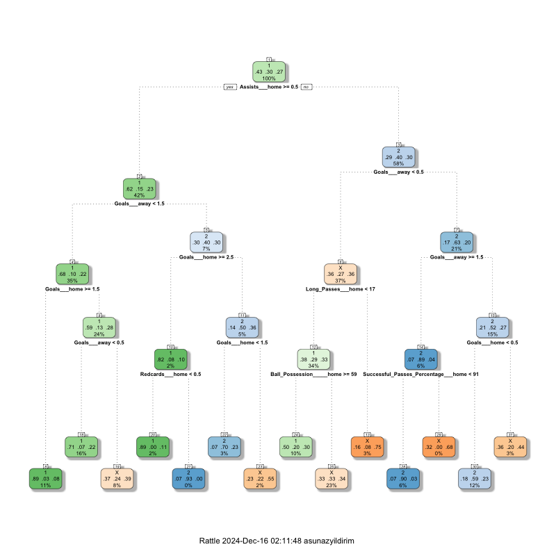

```python
formula = "result ~ halftime + minute + Accurate_Crosses___away + Accurate_Crosses___home" \
          "+Assists___away + Assists___home + Attacks___away + Attacks___home + Ball_Possession_____away" \
          "+Ball_Possession_____home + Ball_Safe___away + Ball_Safe___home + Challenges___away + Challenges___home" \
          "+Corners___away + Corners___home + Counter_Attacks___away + Counter_Attacks___home + Dangerous_Attacks___away" \
          "+Dangerous_Attacks___home + Dribble_Attempts___away + Dribble_Attempts___home + Fouls___away + Fouls___home" \
          "+Free_Kicks___away +Free_Kicks___home +Goal_Attempts___away +Goal_Attempts___home +Goal_Kicks___away " \
          "+Goal_Kicks___home +Goals___away +Goals___home +Headers___away +Headers___home +Hit_Woodwork___away " \
          "+Hit_Woodwork___home +Injuries___away +Injuries___home +Interceptions___away +Interceptions___home" \
          "+Key_Passes___away +Key_Passes___home +Long_Passes___away +Long_Passes___home +Offsides___away +Offsides___home" \
          "+Passes___away +Passes___home +Penalties___away +Penalties___home +Redcards___away +Redcards___home +Saves___away " \
          "+Saves___home +Score_Change___away +Score_Change___home +Shots_Blocked___away +Shots_Blocked___home +Shots_Insidebox___away" \
          "+Shots_Insidebox___home +Shots_Off_Target___away +Shots_Off_Target___home +Shots_On_Target___away +Shots_On_Target___home" \
          "+Shots_Outsidebox___away +Shots_Outsidebox___home +Shots_Total___away +Shots_Total___home +Substitutions___away" \
          "+Substitutions___home +Successful_Dribbles___away +Successful_Dribbles___home +Successful_Headers___away" \
          "+Successful_Headers___home +Successful_Interceptions___away +Successful_Interceptions___home +Successful_Passes___away" \
          "+Successful_Passes___home +Successful_Passes_Percentage___away +Successful_Passes_Percentage___home +Tackles___away" \
          "+Tackles___home +Throwins___away +Throwins___home +Total_Crosses___away +Total_Crosses___home +Yellowcards___away " \
          "+Yellowcards___home +Yellowred_Cards___away +Yellowred_Cards___home"
control= rpart.rpart_control(cp=0.0,maxdepth=4)
r_model = r.rpart(formula, data=r_df, method="class", control= control)
print(r_model)
plot_file = "decision_tree.png"
grdevices.png(file=plot_file, width=800, height=800)
rattle.fancyRpartPlot(r_model)
grdevices.dev_off()
if os.path.exists(plot_file):
    display(Image(filename=plot_file))
else:
    print(f"Plot file {plot_file} not found!")
```

I train a second decision tree by excluding home, away, draw odds to examine how match-related variables affect the outcome of the game. I want to see which match-related metrices arise as splitting variables when the market information is absent. Under this condition, the splitting variables are Assists - home, Goals - away, Goals - home, Red cards - home, Long - Passes - home, Ball Possession -home, Successful Passes Percentage - home. If we evaluate the decision tree as a whole, it produces reasonable results. Assist and goals are key features that directly influence the outcome of the game; therefore, it makes sense that they are key predictors in the decision tree. The tree uses Goals - away and Goals - home multiple times as splitting variables, demonstrating that goals are the most straightforward indicator of a game's progress.  
The decision tree first uses goals and assists as indicators to determine whether the home team is creating good scoring chances. To illustrate, if the home team has one or more assists (Node 1), the home team has a strong chance of winning (Nodes 8,18 and 20). After looking at the home team's offensive performance, it checks if the away team can respond. Multiple away goals or home red cards may result in an away win (Node 21) or a draw (Node 23). Without odds, factors such as ball possession, successful passes percentage, and red cards become more significant. These factors affect match outcomes in cases where the results are more balanced or less obvious. Since I removed the odds, it has become difficult to determine whether they are efficient or not. When the odds are absent, the model only considers match conditions and ignores how the market assessed such conditions.

```
n= 29051

node), split, n, loss, yval, (yprob)
      * denotes terminal node

 1) root 29051 16308 1 (0.43864239 0.30081581 0.26054181)
   2) away_odds>=2.61 18604  7869 1 (0.57702645 0.15201032 0.27096323)
     4) away_odds>=6.75 6540  1246 1 (0.80948012 0.05810398 0.13241590) *
     5) away_odds< 6.75 12064  6623 1 (0.45101127 0.20291777 0.34607095)
      10) home_odds< 1.925 4501  2080 1 (0.53788047 0.14530104 0.31681848) *
      11) home_odds>=1.925 7563  4543 1 (0.39931244 0.23720746 0.36348010)
        22) away_odds< 3.225 3332  1966 1 (0.40996399 0.29441777 0.29561825) *
        23) away_odds>=3.225 4231  2467 X (0.39092413 0.19215316 0.41692271) *
   3) away_odds< 2.61 10447  4536 2 (0.19220829 0.56580837 0.24198334)
     6) away_odds>=1.47 7645  3985 2 (0.23937214 0.47874428 0.28188358) *
     7) away_odds< 1.47 2802   551 2 (0.06352605 0.80335475 0.13311920)
      14) Goal_Attempts___away>=0.5 2340   372 2 (0.06666667 0.84102564 0.09230769) *
      15) Goal_Attempts___away< 0.5 462   179 2 (0.04761905 0.61255411 0.33982684)
        30) Throwins___home< 6.5 365   102 2 (0.02739726 0.72054795 0.25205479) *
        31) Throwins___home>=6.5 97    32 X (0.12371134 0.20618557 0.67010309) *
```

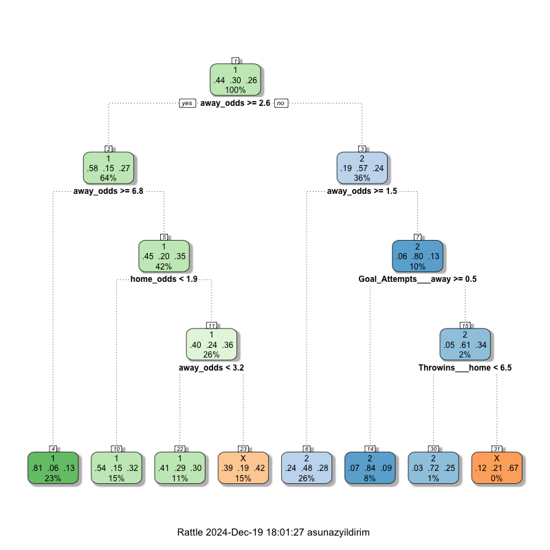

```python
match_data_tree_first_half =match_data[(match_data['halftime'] == '1st-half') & (match_data['suspended'] == False) & (match_data['stopped'] == False)]
match_data_tree_first_half.loc[:, 'result'] = match_data_tree_first_half['result'].astype('category')
match_data_tree_first_half = match_data_tree_first_half.copy()
match_data_tree_first_half.rename(columns={ '1': 'home_odds', '2': 'away_odds', 'X': 'draw_odds'}, inplace=True)
match_data_tree_first_half.columns = match_data_tree_first_half.columns.str.replace(r'[^0-9a-zA-Z_]', '_', regex=True)
r_df = pandas2ri.py2rpy(match_data_tree_first_half)
formula = "result ~ minute + home_odds + away_odds + draw_odds + Accurate_Crosses___away + Accurate_Crosses___home" \
          "+Assists___away + Assists___home + Attacks___away + Attacks___home + Ball_Possession_____away" \
          "+Ball_Possession_____home + Ball_Safe___away + Ball_Safe___home + Challenges___away + Challenges___home" \
          "+Corners___away + Corners___home + Counter_Attacks___away + Counter_Attacks___home + Dangerous_Attacks___away" \
          "+Dangerous_Attacks___home + Dribble_Attempts___away + Dribble_Attempts___home + Fouls___away + Fouls___home" \
          "+Free_Kicks___away +Free_Kicks___home +Goal_Attempts___away +Goal_Attempts___home +Goal_Kicks___away " \
          "+Goal_Kicks___home +Goals___away +Goals___home +Headers___away +Headers___home +Hit_Woodwork___away " \
          "+Hit_Woodwork___home +Injuries___away +Injuries___home +Interceptions___away +Interceptions___home" \
          "+Key_Passes___away +Key_Passes___home +Long_Passes___away +Long_Passes___home +Offsides___away +Offsides___home" \
          "+Passes___away +Passes___home +Penalties___away +Penalties___home +Redcards___away +Redcards___home +Saves___away " \
          "+Saves___home +Score_Change___away +Score_Change___home +Shots_Blocked___away +Shots_Blocked___home +Shots_Insidebox___away" \
          "+Shots_Insidebox___home +Shots_Off_Target___away +Shots_Off_Target___home +Shots_On_Target___away +Shots_On_Target___home" \
          "+Shots_Outsidebox___away +Shots_Outsidebox___home +Shots_Total___away +Shots_Total___home +Substitutions___away" \
          "+Substitutions___home +Successful_Dribbles___away +Successful_Dribbles___home +Successful_Headers___away" \
          "+Successful_Headers___home +Successful_Interceptions___away +Successful_Interceptions___home +Successful_Passes___away" \
          "+Successful_Passes___home +Successful_Passes_Percentage___away +Successful_Passes_Percentage___home +Tackles___away" \
          "+Tackles___home +Throwins___away +Throwins___home +Total_Crosses___away +Total_Crosses___home +Yellowcards___away " \
          "+Yellowcards___home +Yellowred_Cards___away +Yellowred_Cards___home"
control= rpart.rpart_control(cp=0.0,maxdepth=4)
r_model = r.rpart(formula, data=r_df, method="class", control= control)
print(r_model)
plot_file = "decision_tree.png"
grdevices.png(file=plot_file, width=800, height=800)
rattle.fancyRpartPlot(r_model)
grdevices.dev_off()
if os.path.exists(plot_file):
    display(Image(filename=plot_file))
else:
    print(f"Plot file {plot_file} not found!")
```

```
n= 23856

node), split, n, loss, yval, (yprob)
      * denotes terminal node

 1) root 23856 13449 1 (0.436242455 0.301014420 0.262743125)
   2) home_odds< 2.15 9999  1331 1 (0.866886689 0.028002800 0.105110511)
     4) home_odds< 1.29 7274   433 1 (0.940472917 0.008386032 0.051141050)
       8) home_odds< 1.115 5028    97 1 (0.980708035 0.003579952 0.015712013)
        16) Successful_Passes_Percentage___home< 93.5 5014    85 1 (0.983047467 0.003589948 0.013362585) *
        17) Successful_Passes_Percentage___home>=93.5 14     2 X (0.142857143 0.000000000 0.857142857) *
       9) home_odds>=1.115 2246   336 1 (0.850400712 0.019145147 0.130454141)
        18) Headers___away>=2.5 2207   305 1 (0.861803353 0.019483462 0.118713185) *
        19) Headers___away< 2.5 39     8 X (0.205128205 0.000000000 0.794871795) *
     5) home_odds>=1.29 2725   898 1 (0.670458716 0.080366972 0.249174312)
      10) Hit_Woodwork___home< 0.5 2145   529 1 (0.753379953 0.065734266 0.180885781)
        20) Redcards___away< 0.5 2039   449 1 (0.779794017 0.069151545 0.151054438) *
        21) Redcards___away>=0.5 106    26 X (0.245283019 0.000000000 0.754716981) *
      11) Hit_Woodwork___home>=0.5 580   289 X (0.363793103 0.134482759 0.501724138)
        22) Goal_Attempts___home< 3.5 166    71 1 (0.572289157 0.174698795 0.253012048) *
        23) Goal_Attempts___home>=3.5 414   165 X (0.280193237 0.118357488 0.601449275) *
   3) home_odds>=2.15 13857  6956 2 (0.125496139 0.498015443 0.376488417)
     6) away_odds< 1.925 6533   931 2 (0.032603704 0.857492729 0.109903567)
      12) home_odds>=14 5033   332 2 (0.007550169 0.934035367 0.058414465)
        24) Successful_Passes_Percentage___away>=54.5 5011   310 2 (0.007583317 0.938136101 0.054280583) *
        25) Successful_Passes_Percentage___away< 54.5 22     0 X (0.000000000 0.000000000 1.000000000) *
      13) home_odds< 14 1500   599 2 (0.116666667 0.600666667 0.282666667) *
     7) away_odds>=1.925 7324  2825 X (0.208356090 0.177362097 0.614281813) *
```

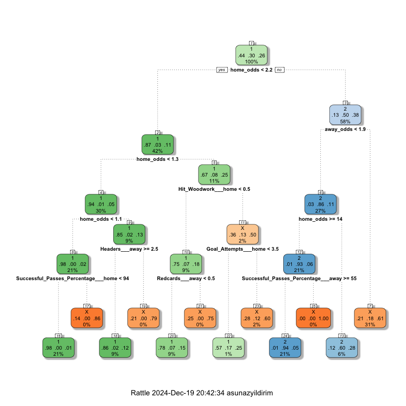

```python
match_data_tree_first_half =cleaned_SH_data
match_data_tree_first_half.loc[:, 'result'] = match_data_tree_first_half['result'].astype('category')
match_data_tree_first_half = match_data_tree_first_half.copy()
match_data_tree_first_half.rename(columns={ '1': 'home_odds', '2': 'away_odds', 'X': 'draw_odds'}, inplace=True)
match_data_tree_first_half.columns = match_data_tree_first_half.columns.str.replace(r'[^0-9a-zA-Z_]', '_', regex=True)
r_df = pandas2ri.py2rpy(match_data_tree_first_half)
formula = "result ~ minute + home_odds + away_odds + draw_odds + Accurate_Crosses___away + Accurate_Crosses___home" \
          "+Assists___away + Assists___home + Attacks___away + Attacks___home + Ball_Possession_____away" \
          "+Ball_Possession_____home + Ball_Safe___away + Ball_Safe___home + Challenges___away + Challenges___home" \
          "+Corners___away + Corners___home + Counter_Attacks___away + Counter_Attacks___home + Dangerous_Attacks___away" \
          "+Dangerous_Attacks___home + Dribble_Attempts___away + Dribble_Attempts___home + Fouls___away + Fouls___home" \
          "+Free_Kicks___away +Free_Kicks___home +Goal_Attempts___away +Goal_Attempts___home +Goal_Kicks___away " \
          "+Goal_Kicks___home +Goals___away +Goals___home +Headers___away +Headers___home +Hit_Woodwork___away " \
          "+Hit_Woodwork___home +Injuries___away +Injuries___home +Interceptions___away +Interceptions___home" \
          "+Key_Passes___away +Key_Passes___home +Long_Passes___away +Long_Passes___home +Offsides___away +Offsides___home" \
          "+Passes___away +Passes___home +Penalties___away +Penalties___home +Redcards___away +Redcards___home +Saves___away " \
          "+Saves___home +Score_Change___away +Score_Change___home +Shots_Blocked___away +Shots_Blocked___home +Shots_Insidebox___away" \
          "+Shots_Insidebox___home +Shots_Off_Target___away +Shots_Off_Target___home +Shots_On_Target___away +Shots_On_Target___home" \
          "+Shots_Outsidebox___away +Shots_Outsidebox___home +Shots_Total___away +Shots_Total___home +Substitutions___away" \
          "+Substitutions___home +Successful_Dribbles___away +Successful_Dribbles___home +Successful_Headers___away" \
          "+Successful_Headers___home +Successful_Interceptions___away +Successful_Interceptions___home +Successful_Passes___away" \
          "+Successful_Passes___home +Successful_Passes_Percentage___away +Successful_Passes_Percentage___home +Tackles___away" \
          "+Tackles___home +Throwins___away +Throwins___home +Total_Crosses___away +Total_Crosses___home +Yellowcards___away " \
          "+Yellowcards___home +Yellowred_Cards___away +Yellowred_Cards___home"
control= rpart.rpart_control(cp=0.0,maxdepth=4)
r_model = r.rpart(formula, data=r_df, method="class", control= control)
print(r_model)
plot_file = "decision_tree.png"
grdevices.png(file=plot_file, width=800, height=800)
rattle.fancyRpartPlot(r_model)
grdevices.dev_off()
if os.path.exists(plot_file):
    display(Image(filename=plot_file))
else:
    print(f"Plot file {plot_file} not found!")
```

I trained a decision tree for the second half of the data which excludes the matches where a red card was given in the first 15 minutes or where a late goal influenced the outcome. Since the are several nodes with 0% of the data. I reset the maximum depth to 3 to obtain a simpler model.

```
n= 23856

node), split, n, loss, yval, (yprob)
      * denotes terminal node

 1) root 23856 13449 1 (0.436242455 0.301014420 0.262743125)
   2) home_odds< 2.15 9999  1331 1 (0.866886689 0.028002800 0.105110511)
     4) home_odds< 1.29 7274   433 1 (0.940472917 0.008386032 0.051141050) *
     5) home_odds>=1.29 2725   898 1 (0.670458716 0.080366972 0.249174312)
      10) Hit_Woodwork___home< 0.5 2145   529 1 (0.753379953 0.065734266 0.180885781) *
      11) Hit_Woodwork___home>=0.5 580   289 X (0.363793103 0.134482759 0.501724138) *
   3) home_odds>=2.15 13857  6956 2 (0.125496139 0.498015443 0.376488417)
     6) away_odds< 1.925 6533   931 2 (0.032603704 0.857492729 0.109903567) *
     7) away_odds>=1.925 7324  2825 X (0.208356090 0.177362097 0.614281813) *
```

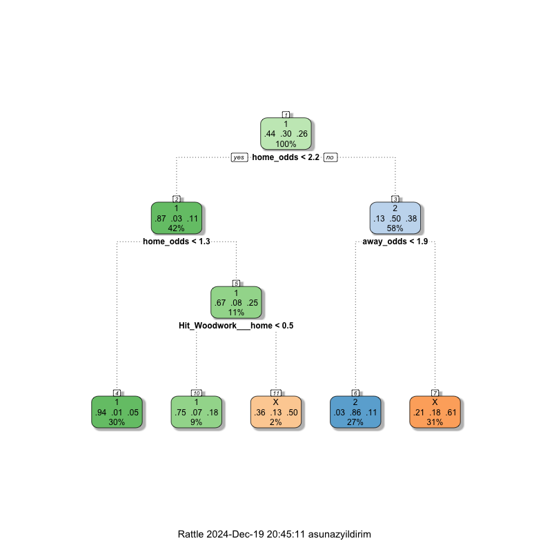

```python
control= rpart.rpart_control(cp=0.0,maxdepth=3)
r_model = r.rpart(formula, data=r_df, method="class", control= control)
print(r_model)
plot_file = "decision_tree.png"
grdevices.png(file=plot_file, width=800, height=800)
rattle.fancyRpartPlot(r_model)
grdevices.dev_off()
if os.path.exists(plot_file):
    display(Image(filename=plot_file))
else:
    print(f"Plot file {plot_file} not found!")
```